# Bayesian vs Frequentist Regression

Matthew Kolisnyk

07/12/2021

The purpose of today’s blog is to compare Bayesian and Frequentist regression, using data from a typical psychology experiment.

Let’s add in our standard libraries. **tidyverse** for loading and cleaning the .csv file, **here** for managing the path, and **broom** for summarizing regression output.

```r
library(tidyverse)
library(here)
library(broom)
```

Load in the data using tidyverse::read_csv and here for finding the correct data in the path. As you can see, the data is stored in a .csv file called “DDM_EXP1”.

```r
data <- read_csv(here("data","DDM_EXP1.csv"),show_col_types = FALSE)
```

Let’s take a look at the file output

```r
str(data)
```

```
## spec_tbl_df [25,000 x 9] (S3: spec_tbl_df/tbl_df/tbl/data.frame)
##  $ block             : num [1:25000] 1 1 1 1 1 1 1 1 1 1 ...
##  $ trial             : num [1:25000] 1 2 3 4 5 6 7 8 9 10 ...
##  $ angle             : num [1:25000] 110 95 110 95 95 95 95 95 110 95 ...
##  $ lr                : num [1:25000] 2 1 0 1 2 1 1 0 1 0 ...
##  $ pre_targ_dur      : num [1:25000] 1.74 2.69 1.97 2.29 1.75 ...
##  $ post_targ_dur     : num [1:25000] 3.26 2.31 3.03 2.71 3.25 ...
##  $ response          : num [1:25000] 2 1 0 1 2 1 1 0 1 0 ...
##  $ RT                : num [1:25000] 0.255 0.376 0 0.461 0.349 0.397 0.404 0 0.351 0 ...
##  $ participant_number: num [1:25000] 1 1 1 1 1 1 1 1 1 1 ...
##  - attr(*, "spec")=
##   .. cols(
##   ..   block = col_double(),
##   ..   trial = col_double(),
##   ..   angle = col_double(),
##   ..   lr = col_double(),
##   ..   pre_targ_dur = col_double(),
##   ..   post_targ_dur = col_double(),
##   ..   response = col_double(),
##   ..   RT = col_double(),
##   ..   participant_number = col_double()
##   .. )
##  - attr(*, "problems")=<externalptr>
```

```r
head(data)
```

```
## # A tibble: 6 x 9
##   block trial angle    lr pre_targ_dur post_targ_dur response    RT
##   <dbl> <dbl> <dbl> <dbl>        <dbl>         <dbl>    <dbl> <dbl>
## 1     1     1   110     2         1.74          3.26        2 0.255
## 2     1     2    95     1         2.69          2.31        1 0.376
## 3     1     3   110     0         1.97          3.03        0 0
## 4     1     4    95     1         2.29          2.71        1 0.461
## 5     1     5    95     2         1.75          3.25        2 0.349
## 6     1     6    95     1         2.40          2.60        1 0.397
## # ... with 1 more variable: participant_number <dbl>
```

These are the results from a standard *go* or *no-go* task. In the data variable, we have standard experiment information such as block, trial, and participant number, but the important experimental information are in the angle and RT column.

We are only interested in trials that have a response (on *go* trials), so let us update the tibble to reflect only the variables we are interested in. *no go* trials are stored as 0s in the lr column.

```r
dataFiltered <-  data %>%
  filter(lr > 0) %>%
  select(angle,RT) %>%
  mutate(dum_angle = case_when(angle == 95 ~ 1,
                               angle == 110 ~ 0))
head(dataFiltered)
```

```
## # A tibble: 6 x 3
##   angle    RT dum_angle
##   <dbl> <dbl>     <dbl>
## 1   110 0.255         0
## 2    95 0.376         1
## 3    95 0.461         1
## 4    95 0.349         1
## 5    95 0.397         1
## 6    95 0.404         1
```

```r
dataFiltered$dum_angle <- as_factor(dataFiltered$dum_angle)
```

A final step was to dummy code our angle column, which makes our model coefficients interpretable. Specifically, our angle coefficient should tell us the unit increase in RT in the *95* condition with the *110* condition as baseline.

Let us train a frequentist linear model and observe our results. We can check out the results of the models using broom::tidy.

```r
fm <- lm(data = dataFiltered, formula = "RT ~ dum_angle")
fcoef <- tidy(fm)
fcoef
```

```
## # A tibble: 2 x 5
##   term        estimate std.error statistic  p.value
##   <chr>          <dbl>     <dbl>     <dbl>    <dbl>
## 1 (Intercept)   0.551    0.00326     169.  0
## 2 dum_angle1    0.0793   0.00461      17.2 1.08e-65
```

You find that your paper has been declined and are expected to make revisions. Reviewer 2 has heard of this new thing called “Bayesian statistics” and claims your results aren’t solid until you include it. How do you go about running Bayesian regression?

The package “rstanarm” is a good place to start, as it contains syntax very similar to base. Let’s start by loading the package. The tidy package also needs to be updated to incorporate Bayesian models. For that we use broom.mixed

```r
library(rstanarm)
library(broom.mixed)
```

rstanarm::stan_glm is the function of choice for bayesian regression. Let’s try it using the same syntax from above. The only difference being the “refresh” argument, which suppresses model output.

```r
bm <- stan_glm(data = dataFiltered, formula = "RT ~ dum_angle", refresh = 0)
bcoef <- tidy(bm)
bcoef
```

```
## # A tibble: 2 x 3
##   term        estimate std.error
##   <chr>          <dbl>     <dbl>
## 1 (Intercept)   0.551    0.00324
## 2 dum_angle1    0.0794   0.00463
```

As we look at angle’s model coefficient we don’t see any difference between using a frequentist and bayesian approach, aside from the slightest different in standard error 0.004613 compared to 0.0046262. What was that damn Reviewer 2 talking about? Another problem is that we no longer have a p-value. How are we going to our results without a p-value?

First, it is a good thing that our results converged across Bayesian and Frequentist approaches. This convergence is often the case and reflects that Bayesian and Frequentist are both genuine solutions to this statistical problem. How they differ (and why there is no p-value) is best understood by looking at the test-statistic.

One crucial difference between Bayesian and Frequentist results is that the test-statistic 0.0794219 and 0.0792577, respectively, is that the Frequentist test-statistic is a **point estimate** (a single value representing a point on a distribution signifying how unusual our results are given the data) whereas the Bayesian test-statistic is a **distribution**.

Let us display how that looks exactly.

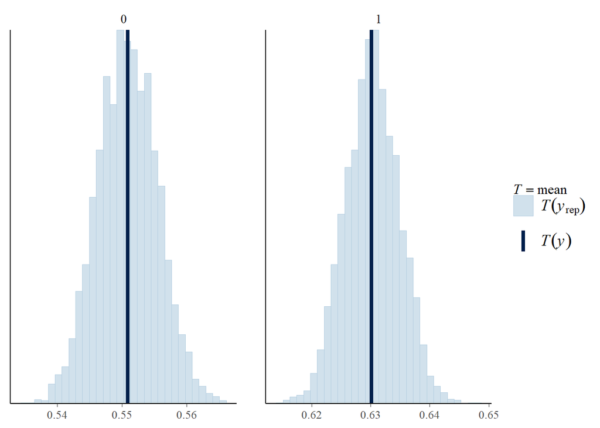

```r
pp <- pp_check(bm, plotfun = "stat_grouped", stat = "mean", group = "dum_angle")
pp
```

What we see is that the test-statistic could take on a number of values. Hence, it doesn’t make sense to have a p-value, since we are given full knowledge about the possible values our test statistic can take. Above we see that the average RT difference between conditions (0 being *110* and 1 being *95*) is our model coefficient from above 0.0794219, but many other plausible values exist, just at different, wholly defined, probabilities.

```r
RT110Pred <- pp$data %>%
  filter(group == 0) %>%
  select(value)
RT95Pred <- pp$data %>%
  filter(group == 1) %>%
  select(value)
```

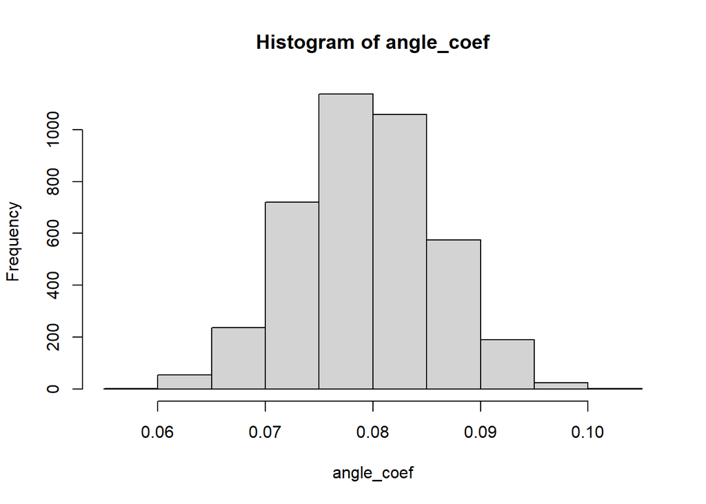

```r
angle_coef <- RT95Pred$value - RT110Pred$value
hist(angle_coef)
```

```r
sum(angle_coef <= 0)/length(angle_coef)
```

```
## [1] 0
```

```r
sum(angle_coef <= 0.06)/length(angle_coef)
```

```
## [1] 5e-04
```

Hopefully you have learned to appreciate the distinctions between interpretations of Bayesian and Frequentist regression!